# Substance Abuse and Mental Health

Arup Ghosh

3/29/2021

# Read the dataset

#https://www.datacamp.com/community/tutorials/logistic-regression-R

```r
#drug.df <- read.csv("Data/drug/small_set_1.tsv",sep="\t",nrows = 25000)[ ,c("UDPYOPI","BOOKED","TXEVRRCVD","BMI2","IRABUPOSSED","IRABUPOSTRQ","IRABUPOSMTH", "IRABUPOSINH","CIGYRBFR","HALLUCEVR","IRCGRGDY","IRABUPOSSTM","YEPHLPHW","YEPPROUD","YEFAIACT","MILTPARNT","IRFAMSOC","INCOME","HLTINMNT","AUUNMTYR","HLTINNOS","MEDICARE","EDUSCHLGO","WRKDPSTWK","YEATNDYR","YESTSMJ","YESTSCIG","YESTSALC","AGE2")]
drug.df <- read.csv("Data/drug/small_set_1.tsv",sep="\t",nrows = 25000)[ ,c("UDPYOPI","YEPHLPHW","YESTSALC","IRABUPOSINH","IRABUPOSMTH","YESTSCIG","IRCGRGDY","TXEVRRCVD")]
```

```r
class(drug.df)
```

```
## [1] "data.frame"
```

```r
names(drug.df)
```

```
## [1] "UDPYOPI"     "YEPHLPHW"    "YESTSALC"    "IRABUPOSINH" "IRABUPOSMTH"
## [6] "YESTSCIG"    "IRCGRGDY"    "TXEVRRCVD"
```

```r
dim(drug.df)
```

```
## [1] 25000     8
```

```r
opioid_user.df <- filter(drug.df, UDPYOPI == "1")
dim(opioid_user.df)
```

```
## [1] 193   8
```

```r
not_opioid_user.df <- filter(drug.df, UDPYOPI == "0")
dim(not_opioid_user.df)
```

```
## [1] 24807     8
```

# Training Data and Test Data split

```r
dt = sort(sample(nrow(not_opioid_user.df), nrow(not_opioid_user.df)*.7))
train_subset<-not_opioid_user.df[dt,]
dim(train_subset)
```

```
## [1] 17364     8
```

```r
test<-not_opioid_user.df[-dt,]
dim(test)
```

```
## [1] 7443    8
```

# Training Data finalization 70% of population who not used opium + 100% population who used opium

```r
train<-rbind(train_subset, opioid_user.df)
dim(train)
```

```
## [1] 17557     8
```

```r
str(train)
```

```
## 'data.frame':    17557 obs. of  8 variables:
##  $ UDPYOPI    : int  0 0 0 0 0 0 0 0 0 0 ...
##  $ YEPHLPHW   : int  99 99 99 99 1 99 99 99 1 99 ...
##  $ YESTSALC   : int  99 99 99 99 94 99 99 99 1 99 ...
##  $ IRABUPOSINH: int  91 91 91 91 0 91 91 91 91 91 ...
##  $ IRABUPOSMTH: int  91 91 91 91 91 93 91 91 91 91 ...
##  $ YESTSCIG   : int  99 99 99 99 94 99 99 99 1 99 ...
##  $ IRCGRGDY   : int  2 91 91 91 91 4 93 2 91 91 ...
##  $ TXEVRRCVD  : int  2 2 2 2 2 1 1 2 91 91 ...
```

```r
summary(train)
```

```
##     UDPYOPI           YEPHLPHW       YESTSALC      IRABUPOSINH
##  Min.   :0.00000   Min.   : 1.0   Min.   : 1.00   Min.   : 0.00
##  1st Qu.:0.00000   1st Qu.:99.0   1st Qu.:99.00   1st Qu.:91.00
##  Median :0.00000   Median :99.0   Median :99.00   Median :91.00
##  Mean   :0.01099   Mean   :77.5   Mean   :78.23   Mean   :90.07
##  3rd Qu.:0.00000   3rd Qu.:99.0   3rd Qu.:99.00   3rd Qu.:91.00
##  Max.   :1.00000   Max.   :99.0   Max.   :99.00   Max.   :93.00
##   IRABUPOSMTH       YESTSCIG        IRCGRGDY       TXEVRRCVD
##  Min.   : 0.00   Min.   : 1.00   Min.   : 1.00   Min.   : 1.00
##  1st Qu.:91.00   1st Qu.:99.00   1st Qu.:91.00   1st Qu.: 2.00
##  Median :91.00   Median :99.00   Median :91.00   Median : 2.00
##  Mean   :90.31   Mean   :78.16   Mean   :76.62   Mean   :24.38
##  3rd Qu.:91.00   3rd Qu.:99.00   3rd Qu.:93.00   3rd Qu.:91.00
##  Max.   :93.00   Max.   :99.00   Max.   :98.00   Max.   :98.00
```

# Logistics Regression

```r
glm.fit <- glm(UDPYOPI ~ YEPHLPHW + YESTSALC + IRABUPOSINH + IRABUPOSMTH+YESTSCIG+IRCGRGDY+TXEVRRCVD ,
               data = train,
               #subset = train,
               family = binomial)
summary(glm.fit)
```

```
##
## Call:
## glm(formula = UDPYOPI ~ YEPHLPHW + YESTSALC + IRABUPOSINH + IRABUPOSMTH +
##     YESTSCIG + IRCGRGDY + TXEVRRCVD, family = binomial, data = train)
##
## Deviance Residuals:
##     Min       1Q   Median       3Q      Max
## -1.2591  -0.1097  -0.1077  -0.0502   3.9816
##
## Coefficients:
##              Estimate Std. Error z value Pr(>|z|)
## (Intercept)  0.576372   0.408356   1.411  0.15811
## YEPHLPHW    -0.014719   0.012296  -1.197  0.23127
## YESTSALC     0.008161   0.015147   0.539  0.59004
## IRABUPOSINH -0.010666   0.003777  -2.824  0.00475 **
## IRABUPOSMTH -0.029477   0.002393 -12.317  < 2e-16 ***
## YESTSCIG     0.003542   0.015601   0.227  0.82040
## IRCGRGDY    -0.018414   0.001823 -10.100  < 2e-16 ***
## TXEVRRCVD   -0.029340   0.007139  -4.110 3.96e-05 ***
## ---
## Signif. codes:  0 '***' 0.001 '**' 0.01 '*' 0.05 '.' 0.1 ' ' 1
##
## (Dispersion parameter for binomial family taken to be 1)
##
##     Null deviance: 2124.9  on 17556  degrees of freedom
## Residual deviance: 1743.8  on 17549  degrees of freedom
## AIC: 1759.8
##
## Number of Fisher Scoring iterations: 10
```

```r
tidy(glm.fit)
```

```
## # A tibble: 8 x 5
##   term        estimate std.error statistic  p.value
##   <chr>          <dbl>     <dbl>     <dbl>    <dbl>
## 1 (Intercept)  0.576     0.408       1.41  1.58e- 1
## 2 YEPHLPHW    -0.0147    0.0123     -1.20  2.31e- 1
## 3 YESTSALC     0.00816   0.0151      0.539 5.90e- 1
## 4 IRABUPOSINH -0.0107    0.00378    -2.82  4.75e- 3
## 5 IRABUPOSMTH -0.0295    0.00239   -12.3   7.33e-35
## 6 YESTSCIG     0.00354   0.0156      0.227 8.20e- 1
## 7 IRCGRGDY    -0.0184    0.00182   -10.1   5.52e-24
## 8 TXEVRRCVD   -0.0293    0.00714    -4.11  3.96e- 5
```

#first 5 probabilities and they are very close to 0%

```r
glm.prob <- predict(glm.fit, test, type = "response")
glm.prob[1:5]
```

```
##            2            3            5            7            8
## 0.0060026114 0.0057868267 0.0060026114 0.0078007899 0.0004433076
```

```r
glm.pred <- ifelse(glm.prob >0, "Yes", "No")
#class(glm.pred)
#not_opioid_user.df <- filter(drug.df, UDPYOPI == "0")
#dim(not_opioid_user.df)
#glm.pred

Test.UDPYOPI = test$UDPYOPI
table(glm.pred, Test.UDPYOPI)
```

```
##         Test.UDPYOPI
## glm.pred    0
##      Yes 7443
```

```r
mean(glm.pred == Test.UDPYOPI)
```

```
## [1] 0
```

# Random Forest Algorithm

-The random forest algorithm works by aggregating the predictions made by multiple decision trees of varying depth. Every decision tree in the forest is trained on a subset of the dataset called the bootstrapped dataset.

-Random forest algorithm is a supervised classification and regression algorithm. As the name suggests, this algorithm randomly creates a forest with several trees.

-Generally, the more trees in the forest the more robust the forest looks like. Similarly, in the random forest classifier, the higher the number of trees in the forest, greater is the accuracy of the results.

```r
rf_classifier = randomForest(UDPYOPI ~ YEPHLPHW + YESTSALC + IRABUPOSINH + IRABUPOSMTH+YESTSCIG+IRCGRGDY+TXEVRRCVD, data=train,ntree=100,mtry=2, importance = TRUE, na.rm = TRUE)
rf_classifier
```

```
##
## Call:
##  randomForest(formula = UDPYOPI ~ YEPHLPHW + YESTSALC + IRABUPOSINH +      IRABUPOSMTH + YESTSCIG + IRCGRGDY + TXEVRRCVD, data = train,      ntree = 100, mtry = 2, importance = TRUE, na.rm = TRUE)
##                Type of random forest: regression
##                      Number of trees: 100
## No. of variables tried at each split: 2
##
##           Mean of squared residuals: 0.01002149
##                     % Var explained: 7.82
```

```r
summary(rf_classifier, na.rm = TRUE)
```

```
##                 Length Class  Mode
## call                7  -none- call
## type                1  -none- character
## predicted       17557  -none- numeric
## mse               100  -none- numeric
## rsq               100  -none- numeric
## oob.times       17557  -none- numeric
## importance         14  -none- numeric
## importanceSD        7  -none- numeric
## localImportance     0  -none- NULL
## proximity           0  -none- NULL
## ntree               1  -none- numeric
## mtry                1  -none- numeric
## forest             11  -none- list
## coefs               0  -none- NULL
## y               17557  -none- numeric
## test                0  -none- NULL
## inbag               0  -none- NULL
## terms               3  terms  call
```

-Mean Decrease Accuracy (%IncMSE) - This shows how much our model accuracy decreases if we leave out that variable.The higher the value of mean decrease accuracy or mean decrease gini score, the higher the importance of the variable to our model.

-IncNodePurity relates to the loss function which by best splits are chosen. The loss function is mse for regression and gini-impurity for classification. More useful variables achieve higher increases in node purities, that is to find a split which has a high inter node ‘variance’ and a small intra node ‘variance’.

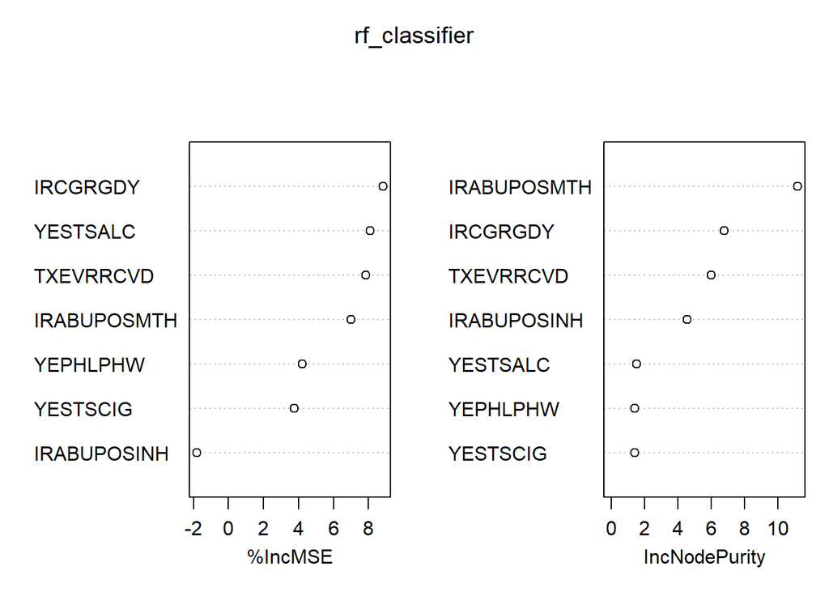

```r
varImpPlot(rf_classifier)
```

```r
importance(rf_classifier)
```

```
##               %IncMSE IncNodePurity
## YEPHLPHW     4.216283      1.423451
## YESTSALC     8.096895      1.500647
## IRABUPOSINH -1.807230      4.555700
## IRABUPOSMTH  7.018918     11.166667
## YESTSCIG     3.776935      1.411129
## IRCGRGDY     8.837624      6.782858
## TXEVRRCVD    7.861796      5.990049
```

```r
prediction_for_table <- predict(rf_classifier,test[,-9], na.rm = TRUE)#IRABUPOSMTH
```

```r
cm = table(observed=test[,8],predicted=prediction_for_table)
#prediction_table
```